# metaheuR: Optimization problems

Borja Calvo, Josu Ceberio, Usue Mori

2017-02-08

When working with an optimization problem there are two aspects that have to be defined: The solution representation and the evaluation function. Depending on the problem and the codification used, there could be solutions that are not feasible.

When we create an optimization problem in `metaheuR` we have to define, at least, a function to evaluate solutions. This function must have a single parameter `solution`, the solution to be evaluated, and must return a numeric value. The implementation of this function will depend on how the solutions are codified, so we need to be very clear about the kind of object that the function requires.

As an example, the function `tspProblem` creates the evaluation function used to solve instances of the *Travelling Salesperson Problem*. In this problem, we have `n` cities and a matrix containing the cost of traveling between any pair of cities. The goal of this problem is to find the minimum cost circuit that passes through every single city once and only once.

In order to create an instance of the problem, we need a cost matrix. For example, we can create a random instance of the problem using a random matrix.

```r
library("metaheuR")
n <- 50
rnd.matrix <- matrix(runif(n^2), ncol=n)
rnd.tsp <- tspProblem(cmatrix=rnd.matrix)
names(rnd.tsp)
```

```
## [1] "evaluate"     "size"         "plotSolution"
```

```r
rnd.solution <- randomPermutation(length = n)
rnd.tsp$evaluate(rnd.solution)
```

```
## [1] 23.24855
```

The package also includes a function to load cost matrices from the well known [TSPlib repository](http://www.iwr.uni-heidelberg.de/groups/comopt/software/TSPLIB95/). This function can be used to load XML files and it accepts both local and remote files, either zip compressed or uncompressed.

```r
cost.matrix <- tsplibParser(file="http://www.iwr.uni-heidelberg.de/groups/comopt/software/TSPLIB95/XML-TSPLIB/instances/brazil58.xml.zip")
```

```
## Processing file corresponding to instance brazil58: 58 cities in Brazil (Ferreira)
```

```r
tsp.brazil <- tspProblem(cost.matrix)
```

Now that we have the evaluation function we can evaluate the identity permutation as a solution to the problem

```r
n <- dim(cost.matrix)[1]
csol <- identityPermutation(n)
tsp.brazil$evaluate(csol)
```

```
## [1] 129267
```

## Problems with restrictions

In some optimization problems there are solutions that may not be feasible. In such cases, the problem generating function must provide functions to handle them. In particular, these functions should provide two additional functions, `valid` and `correct`, with only one input parameter, `solution`. The first function should output `TRUE` if the introduced solution is valid and `FALSE` otherwise. The second function should modify non-valid solutions in some way in order to make them valid.

An example of this kind of problem is the Knapsack Problem. We have a knapsack and a list of items. Each item has a *weight* and a *value*, and the knapsack has a maximum capacity. The goal is to fill the knapsack with items, maximizing the total value of them but without surpassing the limit of the knapsack. We can create a random knapsack problem generating two random vectors which correspond to the weights and values and a random value which defines the limit of the knapsack. To make it more realistic, the values will be correlated with the weights and the limit will be determined by summing the weight of some random items.

```r
n <- 10
weight <- runif(n)
value <- weight + 0.2 * runif(n)
capacity <- sum(sample(weight, size=0.25 * n, replace=FALSE))
ksp <- knapsackProblem(weight=weight, value=value, limit=capacity)
names(ksp)
```

```
## [1] "evaluate" "valid"    "correct"
```

The function `knapsackProblem` returns functions that can be used to check and correct any solution. We can test them with a solution that is obviously non-valid, the one that includes all the items. In this problem the solutions are represented as vectors of logic values, so the solution that includes all the items in the knapsack is a vector of size 10 where all the values are `TRUE`.

```r
all.in.solution <- rep(TRUE, n)
ksp$valid(all.in.solution)
```

```
## [1] FALSE
```

```r
corrected.solution <- ksp$correct(all.in.solution)
ksp$valid(corrected.solution)
```

```
## [1] TRUE
```

In this case, the non-valid solutions are corrected by consecutively removing the items that have the highest weight/value ratio, until the limit is respected.

In some other problems, unfeasible solutions are handled by adding a penalization term in the evaluation function. The package also incorporates a problem implementation that includes this posibility, the `misProblem` function.

This function creates the functions needed to solve Maximum Independece Set (MIS) problems. In these problems, given a graph, the goal is finding the biggest subset of nodes such that there is no link between any two nodes in the subset. Such a subset is called *independent set*, and the solution to the problem is the maximum one, that is, the biggest *independet set*.

The `misProblem` function has two parameters, `graph` and `penalization`. The first parameter is the graph representing the instance of the problem. The second one is used to penalize non valid solutions, i.e., subsets of nodes that are not independent. The penalization term is computed as the product of the parameter introduced (`penalization`) and the number of nodes that violate the independence condition.

Let us see the effect of the penalization in an example based on a random graph.

```r
set.seed(1)
library(igraph)
n <- 100
rnd.graph <- random.graph.game (n=n, p.or.m=0.05)
misp <- misProblem(graph=rnd.graph, penalization=0)
misp.penalized <- misProblem(graph=rnd.graph, penalization=0.5)
```

We have created two versions of the problem, with and without penalization. Now we create a random subset of the nodes and check the evaluation assigned by each of the problems.

```r
rnd.solution <- runif(n) > 0.4
misp$valid(rnd.solution)
```

```
## [1] FALSE
```

```r
misp$evaluate(rnd.solution)
```

```
## [1] -62
```

```r
misp.penalized$evaluate(rnd.solution)
```

```
## [1] -33.5
```

Note that the evaluations are negative. This is because the objective in MIS problems is maximizing the size of the independent set. However, in the package, all the algorithms are programmed to minimize the objective function, so in such situations we replace the original objective function $f$ (in this case, the size of the set) with a new function $g=-f$. We can see this by typing:

```r
misp$evaluate
```

```
## function (solution)
## {
##     ev <- -1 * (sum(solution) - penalization * countViolations(solution))
##     return(ev)
## }
## <environment: 0x87a0cc0>
```

Therefore, the smallest solution the better, that is, penalization terms will increase the value of the objective function.

If we correct the solution, then it will become a feasible solution, it will not have any penalization and, thus, the evaluation will be the same with both versions of the problem.

```r
valid.solution <- misp$correct(rnd.solution)
misp$evaluate(valid.solution)
```

```
## [1] -15
```

```r
misp.penalized$evaluate(valid.solution)
```

```
## [1] -15
```

## Additional functions

In some problem implementations we can find additional functions that may help in visualizing solutions. In the particular case of graph problems, the problem generating function returns a function called `plot`, that can be used to plot any solution in the actual graph.

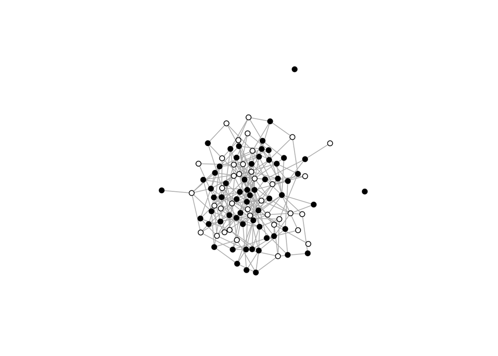

```r
misp$plot(rnd.solution, node.size=5)
```

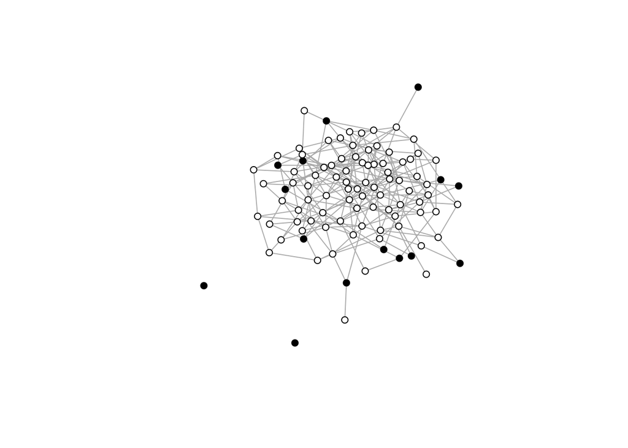

```r
misp$plot(valid.solution)
```

## List of functions in the package

The complete list of problems implemented in the current vesion of the packages is the following

| Problem | Function |
| --- | --- |
| Traveling Salesperson Problem | `tspProblem` |
| Knapsack Problem | `knpasackProblem` |
| Graph Colorig Problem | `graphColoringProblem` |
| Maximum Independent Set Problem | `misProblem` |